# test_thebelab

# Introduction to Data Science

## Loading a spreadsheet-like dataset

Often, the first thing we need to do in data analysis is to load a dataset into R. When we bring spreadsheet-like (think Microsoft Excel tables) data, generally shaped like a rectangle, into R it is represented as what we call a *data frame* object. It is very similar to a spreadsheet where the rows are the collected observations and the columns are the variables.

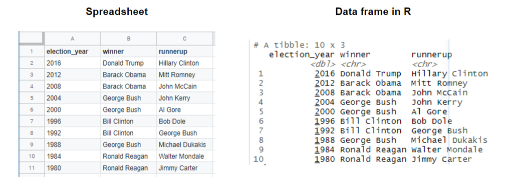

The first kind of data we will learn how to load into R (as a data frame) is the spreadsheet-like *comma-separated values* format (`.csv` for short). These files have names ending in `.csv`, and can be opened open and saved from common spreadsheet programs like Microsoft Excel and Google Sheets. For example, a `.csv` file named `state_property_vote.csv` [is included with the code for this book](https://github.com/UBC-DSCI/introduction-to-datascience/blob/master/data/state_property_data.csv). This file— originally from [Data USA](https://datausa.io/)—has US state-level property, income, population and voting data from 2015 and 2016. If we were to open this data in a plain text editor, we would see each row on its own line, and each entry in the table separated by a comma:

```
state,med_income,med_prop_val,population,mean_commute_minutes,party
AK,64222,197300,733375,10.46830207,Republican
AL,36924,94800,4830620,25.30990746,Republican
AR,35833,83300,2958208,22.40108933,Republican
AZ,44748,128700,6641928,20.58786,Republican
CA,53075,252100,38421464,23.38085172,Democrat
CO,48098,198900,5278906,19.50792188,Democrat
CT,69228,246450,3593222,24.349675,Democrat
DC,70848,475800,647484,28.2534,Democrat
DE,54976,228500,926454,24.45553333,Democrat
```

To load this data into R, and then to do anything else with it afterwards, we will need to use something called a *function.* A function is a special word in R that takes in instructions (we call these *arguments*) and does something. The function we will use to read a `.csv` file into R is called `read_csv`.

In its most basic use-case, `read_csv` expects that the data file:

- has column names (or *headers*),
- uses a comma (`,`) to separate the columns, and
- does not have row names.

Below you’ll see the code used to load the data into R using the `read_csv` function. But there is one extra step we need to do first. Since `read_csv` is not included in the base installation of R, to be able to use it we have to load it from somewhere else: a collection of useful functions known as a *library*. The `read_csv` function in particular is in the `tidyverse` library (more on this later), which we load using the `library` function.

Next, we call the `read_csv` function and pass it a single argument: the name of the file, `"state_property_vote.csv"`. We have to put quotes around filenames and other letters and words that we use in our code to distinguish it from the special words that make up R programming language. This is the only argument we need to provide for this file, because our file satifies everthing else the `read_csv` function expects in the default use-case (which we just discussed). Later in the course, we’ll learn more about how to deal with more complicated files where the default arguments are not appropriate. For example, files that use spaces or tabs to separate the columns, or with no column names.

> clicking the below button will make this book interactive and that could take some times to strat. Be patient…

```r
us_data <- readr::read_csv("https://raw.githubusercontent.com/UBC-DSCI/introduction-to-datascience/master/state_property_vote.csv")
readr::write_csv(us_data, "state_property_vote.csv")
```

```r
library(tidyverse)
read_csv("state_property_vote.csv")
```

```
## # A tibble: 52 x 6
##    state med_income med_prop_val population mean_commute_minutes party
##    <chr>      <dbl>        <dbl>      <dbl>                <dbl> <chr>
##  1 AK         64222       197300     733375                 10.5 Republican
##  2 AL         36924        94800    4830620                 25.3 Republican
##  3 AR         35833        83300    2958208                 22.4 Republican
##  4 AZ         44748       128700    6641928                 20.6 Republican
##  5 CA         53075       252100   38421464                 23.4 Democrat
##  6 CO         48098       198900    5278906                 19.5 Democrat
##  7 CT         69228       246450    3593222                 24.3 Democrat
##  8 DC         70848       475800     647484                 28.3 Democrat
##  9 DE         54976       228500     926454                 24.5 Democrat
## 10 FL         43355       125600   19645772                 24.8 Republican
## # … with 42 more rows
```

Above you can also see something neat that Jupyter does to help us understand our code: it colours text depending on its meaning in R. For example, you’ll note that functions get bold green text, while letters and words surrounded by quotations like filenames get blue text.

> **In case you want to know more (optional):** We use the `read_csv` function from the `tidyverse` instead of the base R function `read.csv` because it’s faster and it creates a nicer variant of the base R data frame called a *tibble*. This has several benefits that we’ll discuss in further detail later in the course.